# Week 4 – Joining and Reshaping Data

## 5. Explore and Visualize

### 5.1 Forest Cover Through Time

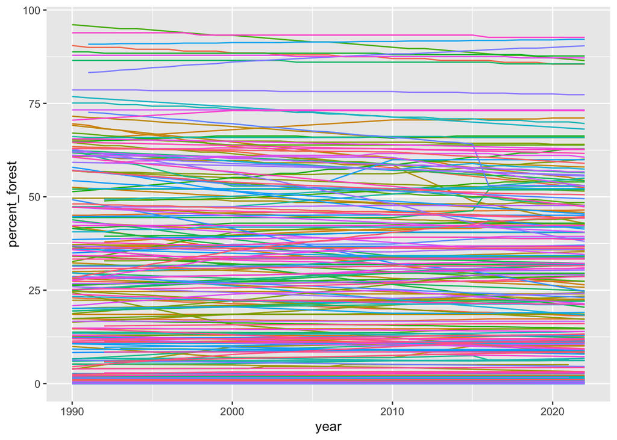

```r
# first, let's plot change in percent cover over time by country
ggplot(joined_cont, aes(x = year)) +
  geom_line(aes(y = percent_forest, color = country)) +
  theme(legend.position = "none")
```

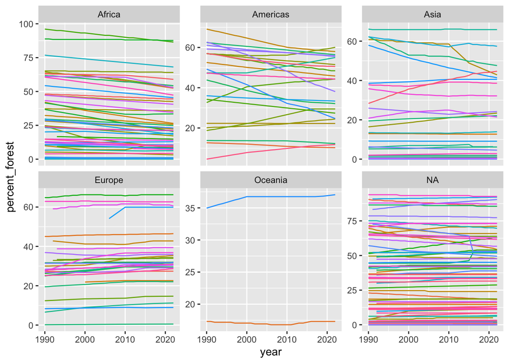

```r
# ok, a bit too busy. Let's subdivide the plot by continent
ggplot(joined_cont, aes(x = year)) +
  geom_line(aes(y = percent_forest, color = country)) +
  facet_wrap(~continent, scales = "free_y") + # <--- ADD THIS
  theme(legend.position = "none")
```

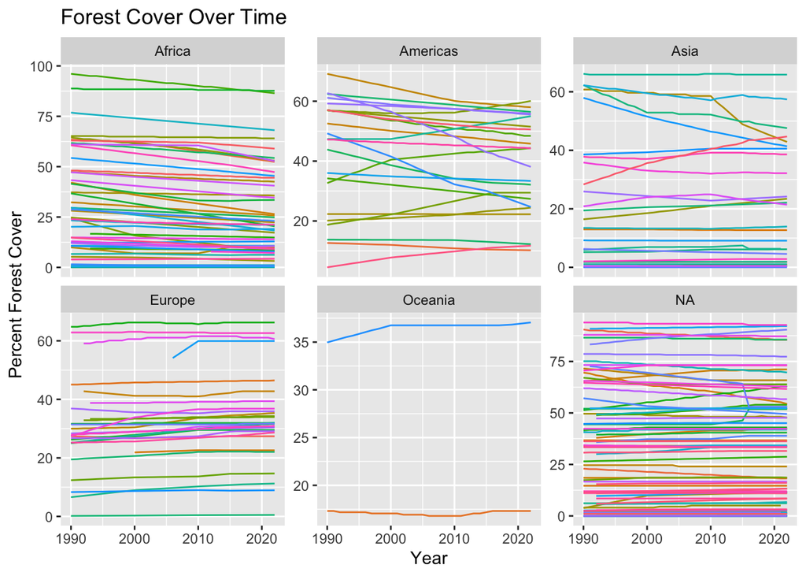

```r
# add labels
ggplot(joined_cont, aes(x = year)) +
  geom_line(aes(y = percent_forest, color = country)) +
  facet_wrap(~continent, scales = "free_y") +
  labs(title = "Forest Cover Over Time",
       x = "Year", y = "Percent Forest Cover", color = "Country") + # <--- ADD THIS
  theme(legend.position = "none")
```

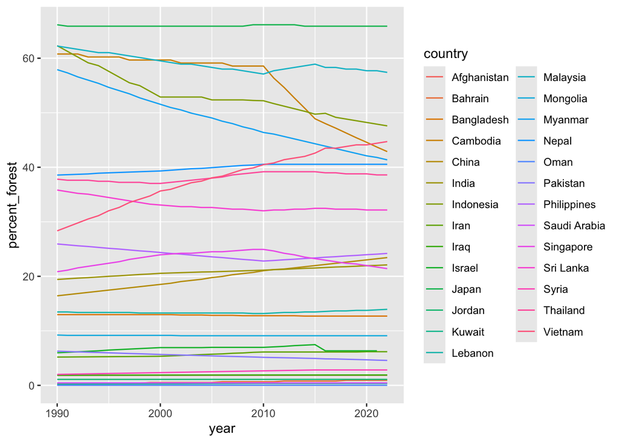

```r
#notice the "Warning Message: Removed 240 rows containing missing values"

# this is OK!! It just means it removed rows where one of the variables was NA, because it cannot plot that row.

# You can also just limit it to one continent now
ggplot(joined_cont %>% filter(continent == "Asia"), aes(x = year)) +
  geom_line(aes(y = percent_forest, color = country))
```

### 5.2 Forest Cover vs. Temperature

```r
# Summarize to one value per country
country_summary <- joined_cont %>%
  group_by(country, continent) %>%
  summarise(
    mean_temp = mean(annual_mean, na.rm = TRUE),
    mean_forest = mean(percent_forest, na.rm = TRUE)
  )
```

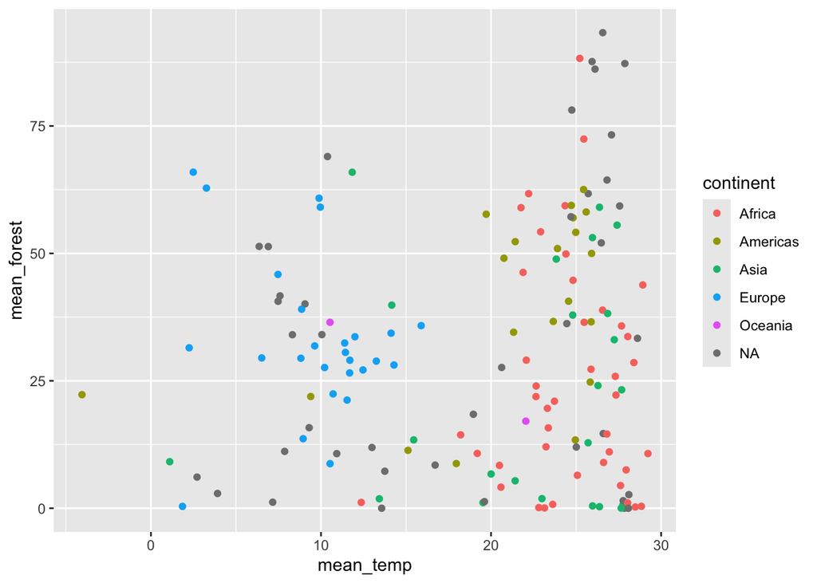

```r
# Plot mean temperature vs mean forest cover
ggplot(country_summary,
       aes(x = mean_temp,
           y = mean_forest,
           color = continent)) +
  geom_point()
```

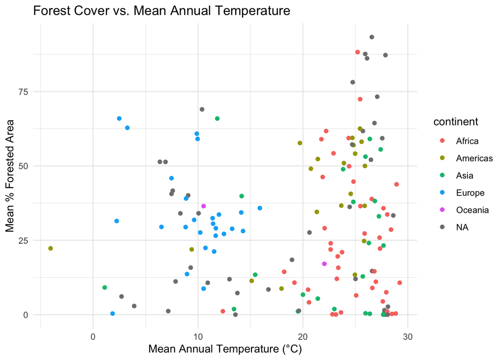

```r
# add labels
ggplot(data = country_summary, aes(x = mean_temp, y = mean_forest, color = continent)) +
  geom_point() +
  labs(title = "Forest Cover vs. Mean Annual Temperature",
       x = "Mean Annual Temperature (°C)",
       y = "Mean % Forested Area") +
  theme_minimal()
```

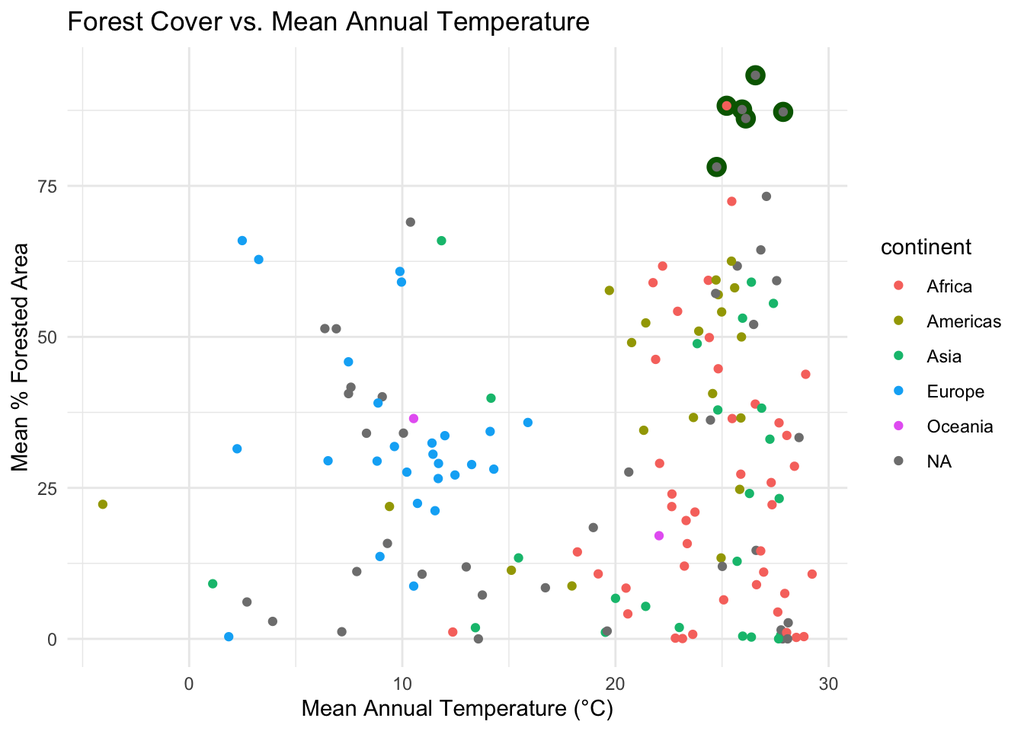

```r
# you can also use the internal use of ggplot geoms to highlight particular data points, using a filter!
ggplot() +
  geom_point(data = country_summary %>% filter(mean_forest > 75), aes(x = mean_temp, y = mean_forest), size = 4, color = "darkgreen") +
  geom_point(data = country_summary, aes(x = mean_temp, y = mean_forest, color = continent)) +
  labs(title = "Forest Cover vs. Mean Annual Temperature",
       x = "Mean Annual Temperature (°C)",
       y = "Mean % Forested Area") +
  theme_minimal()
```

# Skills Application – Practice Prompts

Try the following short exercises using either your **own dataset** or the **Week 4 example datasets**: in `R Course Materials for Students > Sample data` - gapminder > avg_daily_income: Mean daily household per capita income (inflation-adjusted)

- gapminder > literacy_rates: Adult literacy rates is the percentage of people aged 15 and above who can read and write short, simple statements

```r
income <- read_csv(here("Sample datasets/avg_daily_income.csv"))
literacy <- read_csv(here("Sample datasets/literacy_rates.csv"))
```

Use either the **Week 4 example datasets** or the optional **Gapminder income and literacy datasets** provided in the shared folder.  
These exercises combine ideas from **Week 3 (grouping & summarizing)** and **Week 4 (joining & reshaping)** — but push them one step further.

1. **Join on a different key variable:**  
   The `climate` dataset includes a **country code** column.  
   Try joining the **`forest_long`** dataset with `climate` using the code variable (`code`) instead of `country`. What happens? How do the number of matched rows differ from joining by `country`?
2. **Compare data completeness:**  
   Use `anti_join()` to find which countries are present in the `forest_long` dataset but missing from `climate`, and vice versa. How many unique countries appear in only one of the two datasets?
3. **Calculate a new summary statistic:**  
   Instead of the mean, compute the **standard deviation** or **range** of percent forest cover across all available years for each country. Which countries show the largest year-to-year variation in forest cover?
4. **Bring in a new dataset:**  
   Reshape the `literacy_rates` dataset to long format and join it with the `forest_long` dataset (by `country` and `year`). Explore whether literacy rates appear to increase or decrease with forest cover using a scatter plot or correlation.
5. **Challenge (multi-join synthesis):**  
   Combine data from `forest_long`, `income`, and `cont` (continent info) to compare regions. Group by `continent` and compute the **average income** and **average percent forest cover** for the most recent year available in both datasets. Which continents have the highest and lowest values?

> Tip: Save each summarized dataset or plot as its own R object so you can reuse them later.

# Key Takeaways

## Data Sources

The datasets used in this week’s lesson come from open global repositories maintained by the World Bank and other organizations that compile long-term environmental data.

- **Climate (Temperature) Data:**  
  Downloaded from [Kaggle: *Mean Temperature for Countries by Year (2014–2022)*](https://www.kaggle.com/datasets/palinatx/mean-temperature-for-countries-by-year-2014-2022?resource=download).  
  This dataset compiles annual mean temperature values for all available countries between 1901 and 2022.
- **Forest Area, Forest Biomass, and Country Area:**  
  Obtained from [Gapminder](https://www.gapminder.org/data/), which aggregates and cleans data originally published by the [World Bank](https://www.worldbank.org/ext/en/home).  
  These datasets provide estimates of total land area, forested area (in km²), and above-ground forest biomass (in metric tons) for countries worldwide.

All data are provided under open-access terms for educational and research use.